# bosker

Bernhard Koschicek

# Bosker Dataset

## Loading of the Dataset

```r
library(foreign)
bagdad_london_finalRestat <- read.dta("C:/Users/bkoschicek/Dropbox/Geschichte Studium/3_Sem/R-repo/04/Bosker_Data/Bosker_Data/bagdad-london--finalRestat.dta")
#bagdad_london_finalRestat
#summary(bagdad_london_finalRestat$year)
#subset(bagdad_london_finalRestat, bagdad_london_finalRestat$year==1800)
```

## What is the chronological extent of this data?

Chronological Begin:

```r
min(bagdad_london_finalRestat$year)
```

```
## [1] 800
```

Chronological End:

```r
max(bagdad_london_finalRestat$year)
```

```
## [1] 1800
```

Summary: (Just for fun)

```r
summary(bagdad_london_finalRestat$year)
```

```
##    Min. 1st Qu.  Median    Mean 3rd Qu.    Max.
##     800    1000    1300    1300    1600    1800
```

## What periods can it be divided into? How can we do that?

Well there are many humanists ways to seperate the data. Here it will just be divided in Medieval and Early Modern Era. We/I decided that it will be the best to split it at 1500, and 1500 is still medieval. We can add other periods but it is always rinse, repeat.

```r
MedievalPeriod <- subset(bagdad_london_finalRestat,  bagdad_london_finalRestat$year <= 1500)
EarlyModernPeriod <- subset(bagdad_london_finalRestat,  bagdad_london_finalRestat$year > 1500)
head(MedievalPeriod)
```

```
##   indicator          city country year arab_peninsula latitude longitude
## 1         1          Graz Austria  800              0   47.067    15.450
## 2         2     Innsbruck Austria  800              0   47.267    11.400
## 3         3    Klagenfurt Austria  800              0   46.625    14.305
## 4         4          Linz Austria  800              0   48.300    14.300
## 5         5      Salzburg Austria  800              0   47.800    13.033
## 6         6 Wien (Vienna) Austria  800              0   48.200    16.367
##   citypop_le10 citypop_le5 sea river hub_3rr rom_road_nohub caravan_hub
## 1            0           0   0     1       0              1           0
## 2            0           0   0     1       1              0           0
## 3            0           0   0     1       0              0           0
## 4            0           0   0     1       0              1           0
## 5            0           0   0     1       1              0           0
## 6            0           0   0     1       1              0           0
##   caravan_nohub elevation_m  rugg10 bishop archbishop capital university
```

[output cut: 90 more lines]

```r
tail(MedievalPeriod)
```

```
##      indicator                                                        city
## 6339       788 Menuf (Manuf, Manuf al Ulya, Minuf, Onouphisanou, Onouphis)
## 6340       789                                                Asyut (Isiu)
## 6341       790                                Aswan (Uswan, Syene, Swenet)
## 6342       791                     Kina (Kuna, Kaine, Qena, Maximanopolis)
## 6343       792                                     Qalyub (Qaliub, Kalyub)
## 6344       793                                                Tanta (Taya)
##      country year arab_peninsula latitude longitude citypop_le10
## 6339   Egypt 1500              0    30.46     30.92           10
## 6340   Egypt 1500              0    27.18     31.17           10
## 6341   Egypt 1500              0    24.08     32.90            0
## 6342   Egypt 1500              0    32.72     26.17           10
## 6343   Egypt 1500              0    30.20     31.20            0
## 6344   Egypt 1500              0    30.78     31.00            0
##      citypop_le5 sea river hub_3rr rom_road_nohub caravan_hub
```

[output cut: 111 more lines]

```r
head(EarlyModernPeriod)
```

```
##      indicator          city country year arab_peninsula latitude
## 6345         1          Graz Austria 1600              0   47.067
## 6346         2     Innsbruck Austria 1600              0   47.267
## 6347         3    Klagenfurt Austria 1600              0   46.625
## 6348         4          Linz Austria 1600              0   48.300
## 6349         5      Salzburg Austria 1600              0   47.800
## 6350         6 Wien (Vienna) Austria 1600              0   48.200
##      longitude citypop_le10 citypop_le5 sea river hub_3rr rom_road_nohub
## 6345    15.450            0           8   0     1       0              1
## 6346    11.400            0           6   0     1       1              0
## 6347    14.305            0           0   0     1       0              0
## 6348    14.300            0           0   0     1       0              1
## 6349    13.033            0           9   0     1       1              0
## 6350    16.367           50          50   0     1       1              0
##      caravan_hub caravan_nohub elevation_m  rugg10 bishop archbishop
```

[output cut: 104 more lines]

```r
tail(EarlyModernPeriod)
```

```
##      indicator                                                        city
## 8718       788 Menuf (Manuf, Manuf al Ulya, Minuf, Onouphisanou, Onouphis)
## 8719       789                                                Asyut (Isiu)
## 8720       790                                Aswan (Uswan, Syene, Swenet)
## 8721       791                     Kina (Kuna, Kaine, Qena, Maximanopolis)
## 8722       792                                     Qalyub (Qaliub, Kalyub)
## 8723       793                                                Tanta (Taya)
##      country year arab_peninsula latitude longitude citypop_le10
## 8718   Egypt 1800              0    30.46     30.92           10
## 8719   Egypt 1800              0    27.18     31.17           15
## 8720   Egypt 1800              0    24.08     32.90            0
## 8721   Egypt 1800              0    32.72     26.17           15
## 8722   Egypt 1800              0    30.20     31.20           10
## 8723   Egypt 1800              0    30.78     31.00           10
##      citypop_le5 sea river hub_3rr rom_road_nohub caravan_hub
```

[output cut: 111 more lines]

## Can you generate a cumulative graph of population over time, divided into these periods?

Here we see two graphs of the cumulative growth of the populations over time. If the ggplot2 works you can see the graph with 2 lines in one.

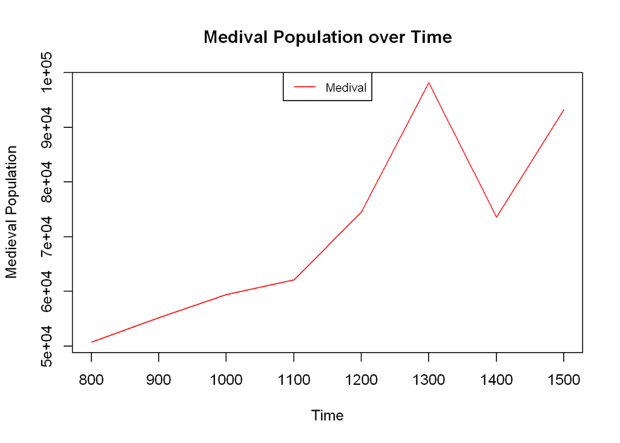

```r
# Create Data Frame for Medieval and Early Medieval Period
data.frame.Medieval <- data.frame("year" = MedievalPeriod$year, "country" = MedievalPeriod$country, "pop" = MedievalPeriod$total_pop_country)
data.frame.EarlyModern <- data.frame("year" = EarlyModernPeriod$year, "country" = EarlyModernPeriod$country, "pop" = EarlyModernPeriod$total_pop_country)

# Make them unique becuase the total population is states in every city, so just need one country per time.
uniqueMedieval = unique(data.frame.Medieval[c("year", "country", "pop")])
aggMedieval = aggregate(uniqueMedieval$pop, by=list(Year=uniqueMedieval$year), FUN=sum)

uniqueEarlyModern = unique(data.frame.EarlyModern[c("year", "country", "pop")])
aggEarlyModern = aggregate(uniqueEarlyModern$pop, by=list(Year=uniqueEarlyModern$year), FUN=sum)

#Plot it!

plot(x = aggMedieval$Year, y = aggMedieval$x, type = "l", col="red", ylab = "Medieval Population", xlab = "Time", main = "Medival Population over Time")
par(new = TRUE)

legend("top", legend=c("Medival"),col=c("red"), lty = 1:2, cex=0.8)
```

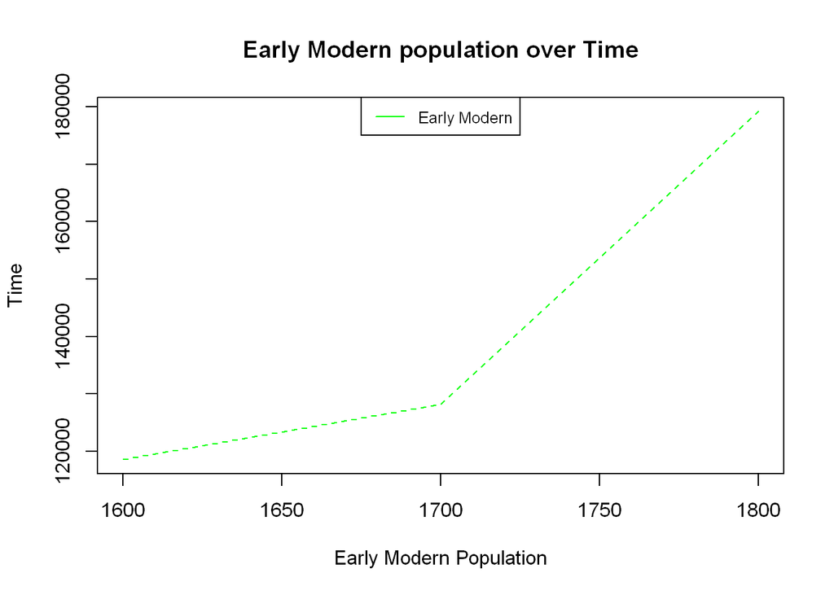

```r
# Plot for Early Modern Population
plot(x = aggEarlyModern$Year, y = aggEarlyModern$x, type = "l", col="green", xlab = "Early Modern Population", ylab = "Time", lty = 2, main = "Early Modern population over Time")
par(new = TRUE)
legend("top", legend=c("Early Modern"),col=c("green"), lty = 1:2, cex=0.8)
```

```r
pop_merge = merge(aggEarlyModern, aggMedieval, by = "Year", all = TRUE)
pop_merge
```

```
##    Year      x.x      x.y
## 1   800       NA 50736.00
## 2   900       NA 55190.33
## 3  1000       NA 59474.00
## 4  1100       NA 62161.00
## 5  1200       NA 74525.33
## 6  1300       NA 98132.33
## 7  1400       NA 73614.67
## 8  1500       NA 93264.00
## 9  1600 118546.3       NA
## 10 1700 128141.0       NA
## 11 1800 179224.0       NA
```

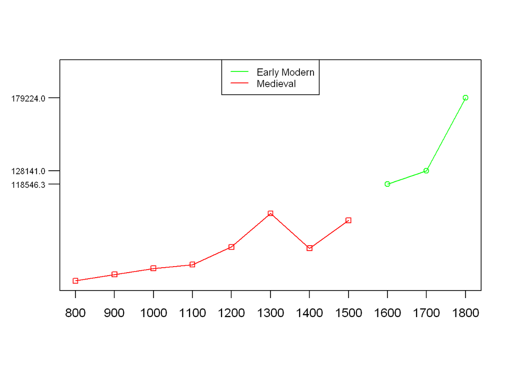

```r
year = unique(bagdad_london_finalRestat$year)

# Plot for together
plot(x = year, pop_merge$x.x, type = "o", col="green", xlab = "Early Modern Population", ylab = "Time",  main = "Early Modern population over Time", axes=FALSE, ann=FALSE, ylim=c(50000, 200000))
axis(1, at=year, lab=year)
axis(2, at=pop_merge$x.x, las=1, tck=-0.05, cex.axis=0.7)
box()
lines(x = unique(bagdad_london_finalRestat$year), pop_merge$x.y, type="o", pch=22, col="red")
par(new = TRUE)
legend("top", legend=c("Early Modern", "Medieval"),col=c("green", "red"), lty = 1:1, cex=0.8)
```

The whole thing with ggplot, which worked, but then suddenly stopped working.

````r
# library(ggplot2)
# ggplot(data = aggEarlyModern, aes(x = aggEarlyModern$Category, y = aggEarlyModern$x)) +
#   geom_line(aes(y = aggEarlyModern$x, x= aggEarlyModern$Category), size=1, color ="green") +
#   xlab("Year") + ylab("Population") +
#   ggtitle("Early Modern Population") +
#   scale_x_continuous(breaks =round(seq(min(range_years_early_modern), max(range_years_early_modern), by = 100),1)) +
#   scale_y_continuous(breaks = round(seq(min(aggEarlyModern$x), max(aggEarlyModern$x), by = 10000),1))
# ```
# ```{r}
# library(ggplot2)
# ggplot(data = aggMedieval, aes(x = aggMedieval$Category, y = aggMedieval$x)) +
#   geom_line(aes(y = aggMedieval$x, x= aggMedieval$Category), size=1, color ="steelblue") +
#   xlab("Year") + ylab("Population") +
#   ggtitle("Medieval Population") +
#   scale_x_continuous(breaks =round(seq(min(range_years_medival), max(range_years_medival), by = 100),1)) +
#   scale_y_continuous(breaks = round(seq(min(aggMedieval$x), max(aggMedieval$x), by = 10000),1))
````

The code gives both graphs in one plot:

```r
# medieval_population <- Medieval.bagdad.sub$citypop_le5
# range_population_medieval <- range(Medieval.bagdad.sub$citypop_le5)
# range_population_early_modern <- range(EarlyModern.bagdad.sub$citypop_le5)
# range_years_early_modern <- range(EarlyModern.bagdad.sub$year)
# years_medival_early_modern <- unique(bagdad_london_finalRestat$year)
#
# library(ggplot2)
# ggplot() +
#   geom_line(data = aggMedieval, aes(y = aggMedieval$x, x= aggMedieval$Category), size=1, color ="steelblue") +
#   geom_line(data= aggEarlyModern, aes(y = aggEarlyModern$x, x= aggEarlyModern$Category), size= 1, color ="green") +
#   xlab("Year") + ylab("Population") +
#   ggtitle("Population over Time") +
#   scale_x_continuous(breaks =round(seq(min(years_medival_early_modern), max(years_medival_early_modern), by = 100),1)) +
#   scale_y_continuous(breaks = round(seq(min(aggMedieval$x), max(aggEarlyModern$x), by =10000),1)) +
#   scale_color_discrete(name="Period",  labels = c("Early Modern Population", "Medival Population"))
```

# North Africa and Europe?

## Can you construct comparative graphs of population in North Africa and Europe (similar to what you did with the Morris dataset). Here you will need to sum up population!

First split the data frame in a African and European Data Frame.

```r
# Create Vector for Europe
Europevector <- c("Austria", "Ireland", "Belgium", "Czech rep.", "Denmark", "Finland", "France", "Germany", "Hungary", "Italy", "Netherlands", "Norway", "Poland", "Portugal", "Slovakia", "Spain", "Sweden", "UK", "Switzerland", "Greece", "Turkey", "Yugoslavia", "Albania", "Bulgaria", "Rumenia", "Luxemburg", "Malta")

# Create Vector for Afrika
NorthAfricavector <- c("Morocco", "Tunesia", "Lybia", "Egypt", "Syria")

# Create the Europe Data Frame
Europe.bagdad <- bagdad_london_finalRestat$country %in% Europevector

europe <- bagdad_london_finalRestat[bagdad_london_finalRestat$country %in% Europevector, ]

# Create the North Afrika Data Frame

NorthAfrica.bagdad <- bagdad_london_finalRestat$country %in% NorthAfricavector

northAfrica<- bagdad_london_finalRestat[bagdad_london_finalRestat$country %in% NorthAfricavector, ]
```

Now we can aggregate the whole thing to collapse the data and plot it in a beautyful plot.

```r
# Aggregate European Data
europe.frame = data.frame("year" = europe$year, "country" = europe$country, "pop" = europe$total_pop_country)
uniqueEurope = unique(europe.frame[c("year", "country", "pop")])
aggEurope = aggregate(uniqueEurope$pop, by=list(Year=uniqueEurope$year), FUN=sum)
aggEurope
```

```
##    Year      x
## 1   800  32751
## 2   900  36642
## 3  1000  40524
## 4  1100  44361
## 5  1200  57402
## 6  1300  79814
## 7  1400  58488
## 8  1500  77464
## 9  1600  99093
## 10 1700 111381
## 11 1800 161664
```

```r
# Aggregate African Data
africa.frame = data.frame("year" = northAfrica$year, "country" = northAfrica$country, "pop" = northAfrica$total_pop_country)
uniqueAfrica = unique(africa.frame[c("year", "country", "pop")])
aggAfrica = aggregate(uniqueAfrica$pop, by=list(Year=uniqueAfrica$year), FUN=sum)
aggAfrica
```

```
##    Year         x
## 1   800  8100.000
## 2   900  9033.333
## 3  1000  9750.000
## 4  1100  8850.000
## 5  1200  8583.333
## 6  1300  9858.333
## 7  1400  7816.667
## 8  1500  8050.000
## 9  1600 10208.333
## 10 1700  8800.000
## 11 1800  8550.000
```

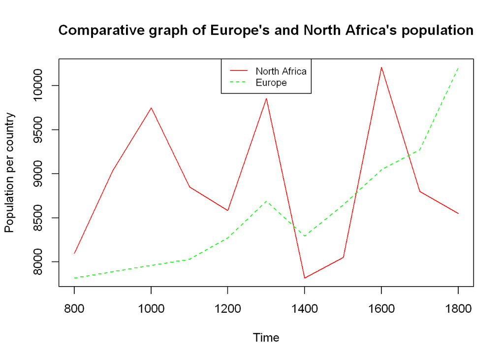

```r
# Plot the whole thing

plot(x = aggAfrica$Year, y = aggAfrica$x, type = "l", col="red", ylab = "Population per country", xlab = "Time", main = "Comparative graph of Europe's and North Africa's population")
par(new = TRUE)

plot(x = aggEurope$Year, y = aggEurope$x, type = "l", col="green", axes = FALSE, xlab = " ", ylab = " ", lty = 2)

legend("top", legend=c("North Africa", "Europe"),col=c("red", "green"), lty = 1:2, cex=0.8)
```

# Habsburg Empire 1500 - 1800 (the Austro-Hungarian Empire)

## When did the Empire had the largest number of cities (based on the data set)?

So first of all the the Austro-Hungarian empire was not until 1867, so the question is not solveable with this dataset. But instead of this construct I took the Habsburg dynasty from 1500 to 1800 based on the data from [habsburger.net](https://www.habsburger.net/de/landkarte). Since the whole task is hideous and I went for the countrys where Habsburg were present at the given time. The code is basically the same just with another vector for the cities.

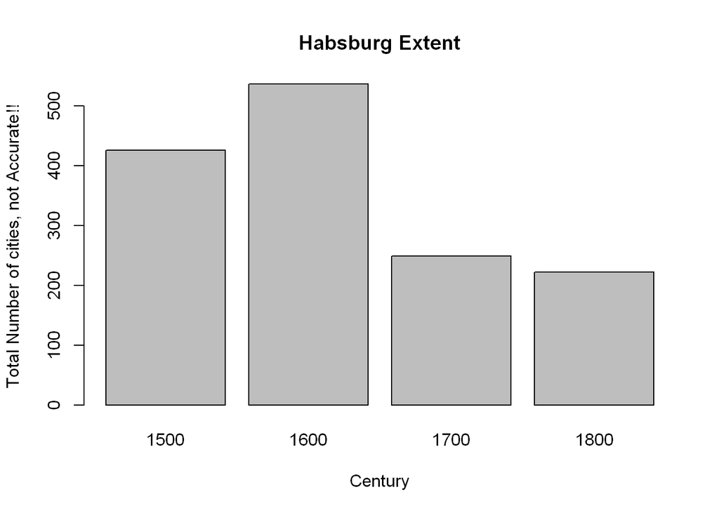

```r
# library(dplyr)
# library(plyr)
# library(tidyr)

# Habsburg at the 15 cent. Just country selection, but the way you do it is the same
habsburg_15_century <- c("Austria", "Spain", "France", "Italy","Belgium", "Netherlands", "Yugoslavia")
habsburg_frame_15 <- subset(bagdad_london_finalRestat, bagdad_london_finalRestat$year == 1500)
habsburg_frame_15 <- habsburg_frame_15[(habsburg_frame_15$country %in% habsburg_15_century), ]
max_15 =nrow(habsburg_frame_15)
#habsburg_frame_15 %>% count(habsburg_frame_15[habsburg_frame_15$year, ])

# Habsburg at the 16 cent. Just country selection, but the way you do it is the same
habsburg_16_century <- c("Austria", "Hungary", "Italy", "Slovakia", "Czech rep.", "Rumenia", "Serbia", "Croatia", "Slovenia", "Galicia", "Ukraine", "Poland", "Luxemburg", "Belgium", "Germany", "France", "Spain", "Portugal", "Netherlands")
habsburg_frame_16 <- subset(bagdad_london_finalRestat, bagdad_london_finalRestat$year == 1600)
habsburg_frame_16 <- habsburg_frame_16[(habsburg_frame_16$country %in% habsburg_16_century), ]
max_16 =  nrow(habsburg_frame_16)
#habsburg_frame_16 %>% count(habsburg_frame_16$year)

#Habsburg at the 17 cent. Just country selection, but the way you do it is the same
habsburg_17_century <- c("Austria", "Hungary", "Italy", "Slovakia", "Czech rep.", "Rumenia", "Serbia", "Croatia", "Slovenia", "Ukraine", "Poland", "Luxemburg", "Belgium", "Netherlands")
habsburg_frame_17 <- subset(bagdad_london_finalRestat, bagdad_london_finalRestat$year == 1700)
habsburg_frame_17 <- habsburg_frame_17[(habsburg_frame_17$country %in% habsburg_17_century), ]
max_17 = nrow(habsburg_frame_17)
#habsburg_frame_17 %>% count(habsburg_frame_17$year)

#Habsburg at the 18 cent. Just country selection, but the way you do it is the same
habsburg_18_century <- c("Austria", "Hungary", "Italy", "Slovakia", "Czech rep.", "Rumenia", "Yugoslavia", "Poland")
habsburg_frame_18 <- subset(bagdad_london_finalRestat, bagdad_london_finalRestat$year == 1800)
habsburg_frame_18 <- habsburg_frame_18[(habsburg_frame_18$country %in% habsburg_18_century), ]
max_18 = nrow(habsburg_frame_18)
#habsburg_frame_18 %>% count(habsburg_frame_18$year)

# Create a Barplot for better visualisation
max_habsburg = c(max_15, max_16, max_17, max_18)
barplot(max_habsburg, main = "Habsburg Extent", xlab = "Century", ylab = "Total Number of cities, not Accurate!!", names.arg=c("1500","1600","1700","1800") )
```

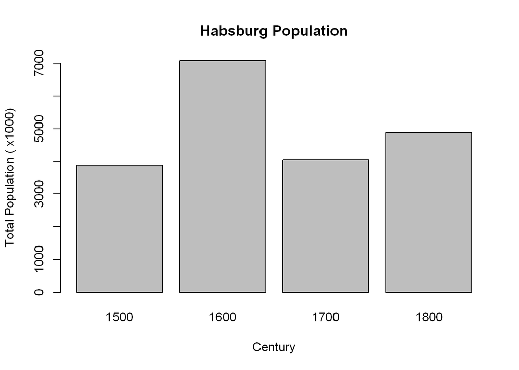

```r
# Habsburg Population
# Since we only operate at country level, the result isn't quite accurate or something, but well it is the solution to the question but without the needed Dataset. I just say it is a hideous task and since the Austro-Hungarian Empire didn't even EXIST before the 19th cent. the question is not possible to resolve with the given dataset.
pop_h_15 = sum(habsburg_frame_15$citypop_le5)
pop_h_16 = sum(habsburg_frame_16$citypop_le5)
pop_h_17 = sum(habsburg_frame_17$citypop_le5)
pop_h_18 = sum(habsburg_frame_18$citypop_le5)

# Create a Barplot for better visualisation
pop_habsburg = c(pop_h_15, pop_h_16, pop_h_17, pop_h_18)
barplot(pop_habsburg, main = "Habsburg Population", xlab = "Century", ylab = "Total Population ( x1000)", names.arg=c("1500","1600","1700","1800") )
```

# Islamdom and Christiandom

## What are the largest cities of Islamdom for each reported period?

We start out by creating an Islamdom dataset. We remove all countries that were at no point part of Islamdom. Add a variable: Islamdom. For any and all cities that are part of a core of Islamdom, we give this variable a value of 1 for all centuries. For cities that are only a part of Islamdom in specific timeframes we make that variable 1 for those times when it was a part of the empire. We remove all cities that were never part of Islamdom. We can then apply max() to the populations of any given time period - again, by subsetting to restrict the timeframe.

## What are the largest western cities of Islamdom between 1000 and 1500 CE?

This is somewhat dependent upon what this question means. If the question is simply about which were the largest cities that were muslim in what we consider the West, it’s easy. We restrict the dataset to the west, and to 1000 to 1500, sort out any cities across all periods that were not muslim (using the muslim variable) and there we have it. A list of all muslim cities in the west, to be sorted by size if so desired. If the question is then of largest and at what time, that can be printed out. If the question is simply which were the largest, a unique() list of cities sorted by size (greater than an arbitrary mark) will provide all fitting cities.

If, however, the question is about the extent of Islamdom, we need to create a full reconstruction of Islamdom, then examine its western reaches city by city for the largest.